# Lab1

Jessica Temporal

August 4, 2016

Download alon.txt: https://drive.google.com/open?id=0B0-8N2fjttG-Xy1sQUNRREk2RUk and read `alon.txt` data

```
##   Gene    norm1    norm2    norm3    norm4    norm5
## 1    1 9164.254 6246.449 2510.325 4028.710 5271.517
## 2    2 6719.529 7823.534 1960.655 3156.159 4740.768
## 3    3 4883.449 5955.835 1566.315 2870.255 3318.514
## 4    4 3718.159 3975.564 3072.816 4417.591 6792.348
## 5    5 2015.221 2002.613 1810.205 1854.106 2632.889
## 6    6 5569.907 2130.543 1673.564 2828.304 5449.207
```

Often in R, our data frames are read in with the gene names as a data column, instead of a row name. By doing the previous step, we are removing the gene names from a data column and setting them to the row names. (Hint: use dimnames(x)[[1]] on the left side of the assignment and cast the first column to character (as.character()) prior to setting the row names).

Setting the row names to the first column, then removing this first column.

```
##      norm1    norm2    norm3    norm4    norm5     norm6
## 1 9164.254 6246.449 2510.325 4028.710 5271.517 14173.054
## 2 6719.529 7823.534 1960.655 3156.159 4740.768  8411.861
## 3 4883.449 5955.835 1566.315 2870.255 3318.514  6042.840
## 4 3718.159 3975.564 3072.816 4417.591 6792.348  8766.046
## 5 2015.221 2002.613 1810.205 1854.106 2632.889  3511.084
## 6 5569.907 2130.543 1673.564 2828.304 5449.207  4878.182
```

There should be 62 samples. If you have 63 samples, you still have the row names in the first data column. Looking at the dimensions of the data.

```
## [1] 2000   62
```

Print the sample names to screen.

```
##  [1] "norm1"   "norm2"   "norm3"   "norm4"   "norm5"   "norm6"   "norm7"
##  [8] "norm8"   "norm9"   "norm10"  "norm11"  "norm12"  "norm13"  "norm14"
## [15] "norm15"  "norm16"  "norm17"  "norm18"  "norm19"  "norm20"  "norm21"
## [22] "norm22"  "tumor1"  "tumor2"  "tumor3"  "tumor4"  "tumor5"  "tumor6"
## [29] "tumor7"  "tumor8"  "tumor9"  "tumor10" "tumor11" "tumor12" "tumor13"
## [36] "tumor14" "tumor15" "tumor16" "tumor17" "tumor18" "tumor19" "tumor20"
## [43] "tumor21" "tumor22" "tumor23" "tumor24" "tumor25" "tumor26" "tumor27"
## [50] "tumor28" "tumor29" "tumor30" "tumor31" "tumor32" "tumor33" "tumor34"
## [57] "tumor35" "tumor36" "tumor37" "tumor38" "tumor39" "tumor40"
```

Plotting one of the tumor samples versus one of the normal samples in an xy scatter plot. Remember that the first argument is the x vector. Label the x and y-axes as ‘normal’ and ‘tumor’, respectively. Title the plot, ‘Tumor sample vs. Normal sample - 2000 genes’.

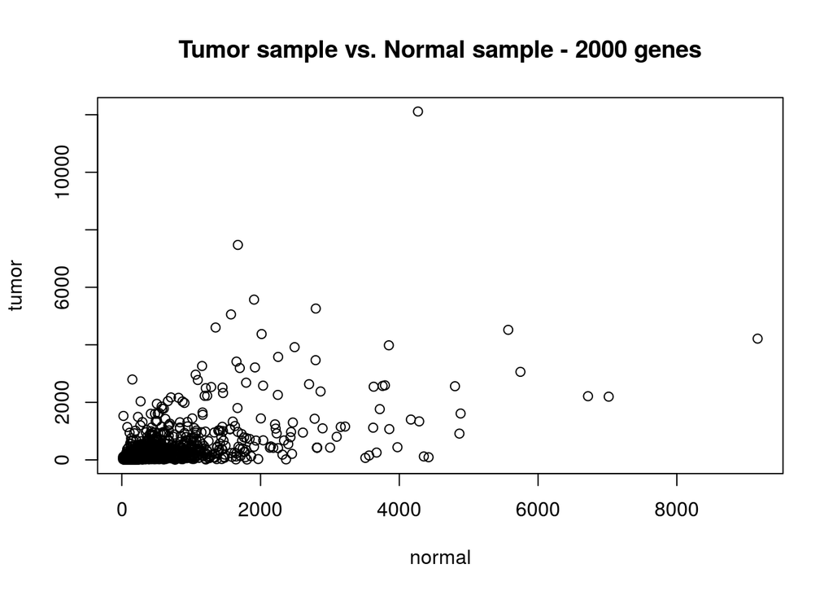

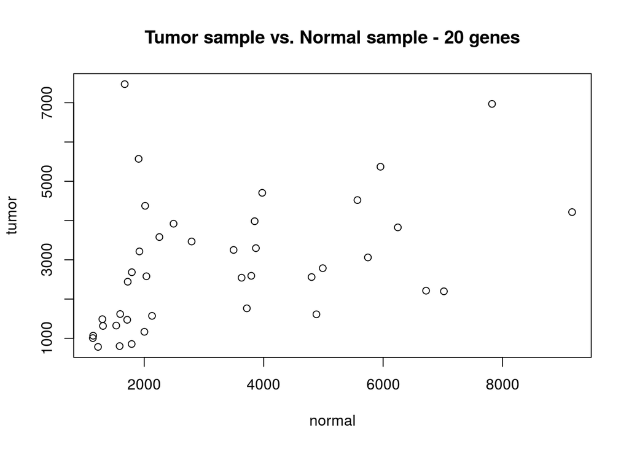

Add a line to connect the points

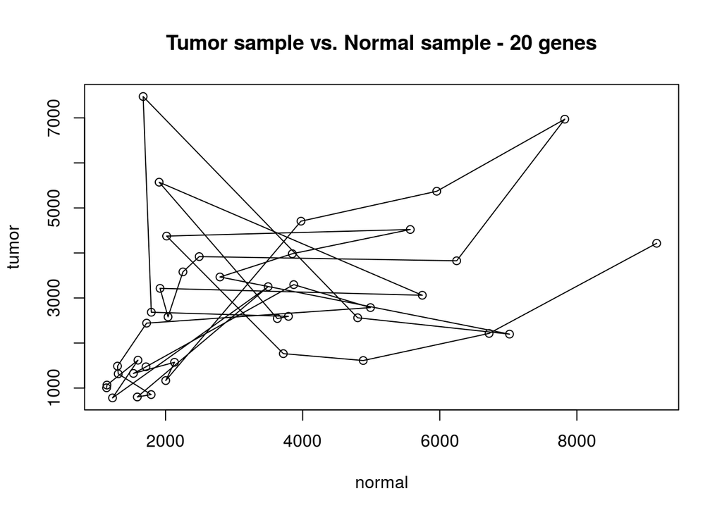

Take the ratio of gene 5 to gene 15 and plot the profile of the gene across all samples. Label each point with the sample name (see text() help and use cex=1).

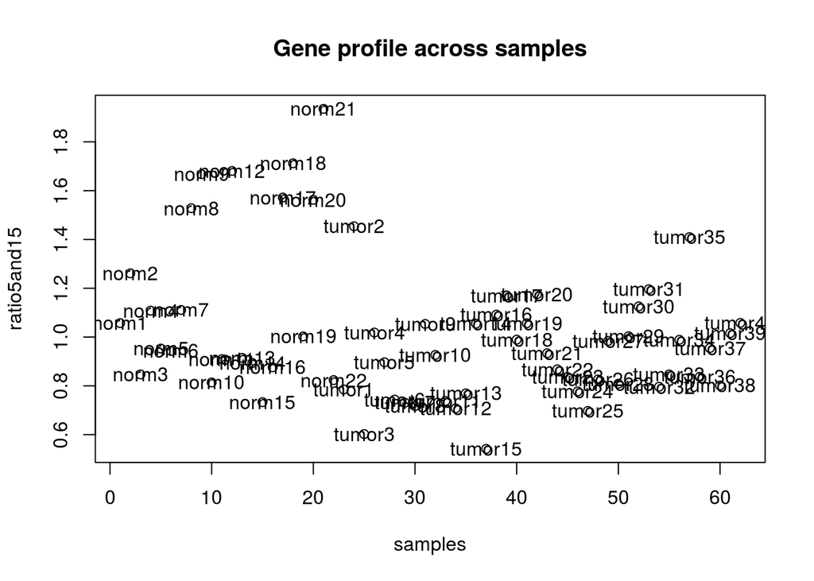